# Data Analysis Project - STAT 420 - Group Project

Luma Vasiljevic(lumav2), Sushanta Panda(panda5)

# Introduction

### Description of the dataset

##### **Dataset Link:**

http://www.statsci.org/data/general/fev.html

##### **Variables in the Dataset**

| VariableName | Category | Description |
| --- | --- | --- |
| ID | Numeric | Uniquely Identified Row |
| Age | Numeric | Age of the child |
| Height | Numeric | Height of the child in inches |
| Sex | Categorical | Sex of the child |
| Smoker | Categorical | Whether the child is a non-smoker or current smoker |
| FEV | Numeric | FEV of the child in litres |

##### **Background information of the dataset**

Note: No citation required for this source (http://www.statsci.org/data/general/fev.html)

### Why is it interesting

This dataset has chosen by us because of personal interests, whether we can predict the child’s FEV with the help of the available predictor, rather going for a Pulmonary Function Test, which will identify any pulmonary disease of a child. And secondly, to do statistical analysis on what are the predictors responsible to increase / decrease the pulmonary function of the child and try to find answer on these lines.

### Why are we creating a model of this Data

In order to **predict the child’s Forced Exporatory Volume (FEV)** based on the Child’s Age, Height, Sex and whether the child is a smoker or not. This will help for kick-start the treatment of the child based on the FEV reading, rather going throgh the Pulmonary Function test.

### Goal of the Model

The goal of the model is to find the best model after going through the several methods, which predict the child’s FEV with minimal error. The best model would be a ballanced choice between accuracy and complexity.

# Methods

First we visualy inspect the data for linearity between FEV and other variables. We also inspect for linearity between transformations of FEV and other variables; i.e. $log(FEV)$ and $FEV^2$

### Load FEV data, Observations

```r
childfev = read.csv("http://www.statsci.org/data/general/fev.txt",
                    sep = "\t",
                    quote = "\"",
                    comment.char = "",
                    stringsAsFactors = FALSE)
childfev$Sex = as.factor(childfev$Sex)
childfev$Smoker = as.factor(childfev$Smoker)

#add log(FEV)
childfev$logFEV=log(childfev$FEV)

#add FEV^2
childfev$sqFEV=childfev$FEV^2
str(childfev)
```

```
## 'data.frame':    654 obs. of  8 variables:
##  $ ID    : int  301 451 501 642 901 1701 1752 1753 1901 1951 ...
##  $ Age   : int  9 8 7 9 9 8 6 6 8 9 ...
##  $ FEV   : num  1.71 1.72 1.72 1.56 1.9 ...
##  $ Height: num  57 67.5 54.5 53 57 61 58 56 58.5 60 ...
##  $ Sex   : Factor w/ 2 levels "Female","Male": 1 1 1 2 2 1 1 1 1 1 ...
##  $ Smoker: Factor w/ 2 levels "Current","Non": 2 2 2 2 2 2 2 2 2 2 ...
##  $ logFEV: num  0.535 0.545 0.542 0.443 0.639 ...
##  $ sqFEV : num  2.92 2.97 2.96 2.43 3.59 ...
```

```r
dim(childfev)
```

```
## [1] 654   8
```

```r
head(childfev$FEV,10)
```

```
##  [1] 1.708 1.724 1.720 1.558 1.895 2.336 1.919 1.415 1.987 1.942
```

From the dataset, the observered data, Age, Heigh are numerical variables, whereas Sex, and Smoker are categorical variables. The FEV is the numerical **response** variable.

##### **Load FEV data:**

Plot variable pairs. $

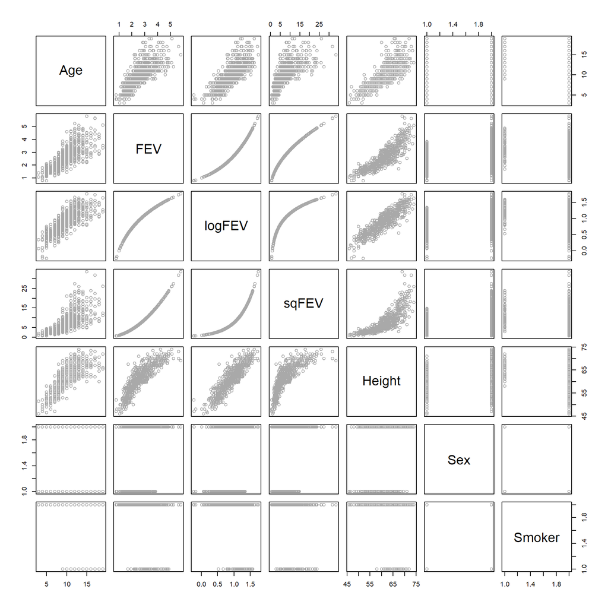

```r
pairs(childfev[c('Age','FEV','logFEV','sqFEV','Height','Sex','Smoker')], col = "darkgrey")
```

$~$ From the pairs plot, we observe correlation between FEV and Height, as well as FEV and Age. The relationships however are not linear. The 2 categorical variable `Sex` and `Smoker` seems to have 2 distinct data. Linearity improves with the log transformation.

**Correlation Matrix**

```r
cor(childfev[c('Age','Height','FEV', 'logFEV', 'sqFEV')])
```

```
##           Age Height    FEV logFEV  sqFEV
## Age    1.0000 0.7919 0.7565 0.7719 0.7093
## Height 0.7919 1.0000 0.8681 0.8920 0.8087
## FEV    0.7565 0.8681 1.0000 0.9767 0.9802
## logFEV 0.7719 0.8920 0.9767 1.0000 0.9170
## sqFEV  0.7093 0.8087 0.9802 0.9170 1.0000
```

The correlation matrix reinforces observations from the plot. The corelation matrix also suggests that `Age` and `Height` are higly corellated with `logFEV` response. We wil also explore the variance inflation factor (VIF) while working on our models.

### Measuring models

The summarize function summarizes metrics of interest for a model. For each model we record:

1. The number of parameters as a measure of model complexity and interpretability
2. Residuals Square Error as a measure of model accuracy
3. Root Mean Square Error as a measure of model accuracy
4. Average Leave One Out Cross Validation Error as a measure of model predictive ability
5. R squared as a measure of predictor potency
6. Adjusted R squared as of trade-off between accuracy and model complexity
7. The p-value of Breusch-Pagan test as a measure of equal noise variance acroos observations
8. The p-value of Shapiro-Wilk test as a measure of ‘normality’ of the noise
9. Max(VIF) as a measure of colinearity between variables
10. The p-value of the significance of regression test

```r
summarize = function(model, plot_title = '',plot=FALSE) {
  sm1 = summary(model)
  sm1
  RSS1 = sum((resid(model)) ^ 2)
  RMSE1 = sqrt(mean(sum((resid(
    model
  )) ^ 2)))
  LOOCV1 = sqrt(mean((resid(model) / (
    1 - hatvalues(model)
  )) ^ 2))
  bp1 = bptest(model)
  st1 = shapiro.test(resid(model))
  f = sm1$fstatistic
  p = pf(f[1], f[2], f[3], lower.tail = FALSE)

  if (plot) { par(mfrow = c(1, 2))
  plot(
    resid(model) ~ fitted(model),
    ylab = "residuals",
    xlab = "fitted",
    cex = 1,
    pch = 1,
    col = "darkgrey",
    main = paste('Fitt. vs. Res. Plot', plot_title)
  )
  abline(h = 0, lwd = 2, col = "darkorange")

  qqnorm(resid(model),
         cex = 1,
         pch = 1,
         col = "darkgrey")
  qqline(resid(model), lwd = 2, col = "darkorange")}

  df = data.frame(
    Metric = c(
      "# of Parameters",
      "RSS",
      "RMSE",
      "RMSE LOOCV",
      "R^2",
      "Adj. R^2",
      "BP p-value",
      "Shapiro test p-value",
      "Colinearity - max(VIF)",
      "Significance of Reg. p-value"
    ),
    Value = c(
      length(coef(model)),
      RSS1,
      RMSE1,
      LOOCV1,
      sm1$r.squared,
      sm1$adj.r.squared,
      bp1$p.value ,
      st1$p.value,
      max(vif(model)),
      p


    )
  )

}
```

### Simple MLR model

The Multiple Linear Regression contains all the predictor in the model, which also includes the dummy variable for the categorical predictor (Sex and Smoker)

```r
mlr_model = lm(logFEV ~ Age + Height + Sex + Smoker, data = childfev)

simple=lm(FEV ~ Age + Height + Sex + Smoker, data = childfev)

summary(mlr_model)
```

```
##
## Call:
## lm(formula = logFEV ~ Age + Height + Sex + Smoker, data = childfev)
##
## Residuals:
##     Min      1Q  Median      3Q     Max
## -0.6328 -0.0866  0.0115  0.0954  0.4070
##
## Coefficients:
##             Estimate Std. Error t value Pr(>|t|)
## (Intercept) -1.99007    0.08189  -24.30  < 2e-16 ***
## Age          0.02339    0.00335    6.98  7.1e-12 ***
## Height       0.04280    0.00168   25.49  < 2e-16 ***
## SexMale      0.02932    0.01172    2.50    0.013 *
## SmokerNon    0.04607    0.02091    2.20    0.028 *
## ---
## Signif. codes:  0 '***' 0.001 '**' 0.01 '*' 0.05 '.' 0.1 ' ' 1
##
## Residual standard error: 0.145 on 649 degrees of freedom
## Multiple R-squared:  0.811,  Adjusted R-squared:  0.809
## F-statistic:  695 on 4 and 649 DF,  p-value: <2e-16
```

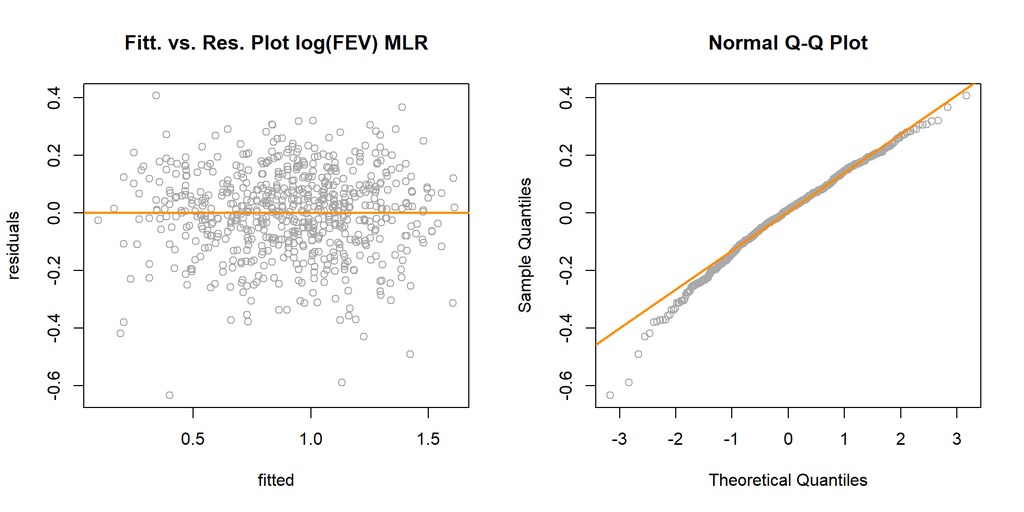

```r
df_mlr_model=summarize(mlr_model,plot_title="log(FEV) MLR",plot=TRUE)
```

```r
kable(df_mlr_model, format = "pandoc", padding = 2)
```

| Metric | Value |
| --- | --- |
| # of Parameters | 5.0000 |
| RSS | 13.7336 |
| RMSE | 3.7059 |
| RMSE LOOCV | 0.1461 |
| R^2 | 0.8106 |
| Adj. R^2 | 0.8095 |
| BP p-value | 0.1881 |
| Shapiro test p-value | 0.0000 |
| Colinearity - max(VIF) | 3.0190 |
| Significance of Reg. p-value | 0.0000 |

```r
summary(simple)
```

```
##
## Call:
## lm(formula = FEV ~ Age + Height + Sex + Smoker, data = childfev)
##
## Residuals:
##     Min      1Q  Median      3Q     Max
## -1.3766 -0.2503  0.0089  0.2559  1.9205
##
## Coefficients:
##             Estimate Std. Error t value Pr(>|t|)
## (Intercept) -4.54422    0.23205  -19.58  < 2e-16 ***
## Age          0.06551    0.00949    6.90  1.2e-11 ***
## Height       0.10420    0.00476   21.90  < 2e-16 ***
## SexMale      0.15710    0.03321    4.73  2.7e-06 ***
## SmokerNon    0.08725    0.05925    1.47     0.14
## ---
## Signif. codes:  0 '***' 0.001 '**' 0.01 '*' 0.05 '.' 0.1 ' ' 1
##
## Residual standard error: 0.412 on 649 degrees of freedom
## Multiple R-squared:  0.775,  Adjusted R-squared:  0.774
## F-statistic:  560 on 4 and 649 DF,  p-value: <2e-16
```

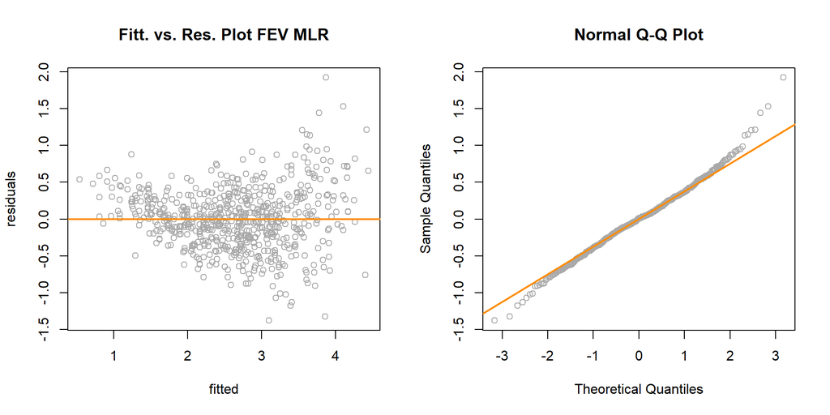

```r
df_simple=summarize(simple,plot_title="FEV MLR",plot=TRUE)
```

```r
kable(df_simple, format = "pandoc", padding = 2)
```

| Metric | Value |
| --- | --- |
| # of Parameters | 5.0000 |
| RSS | 110.2796 |
| RMSE | 10.5014 |
| RMSE LOOCV | 0.4145 |
| R^2 | 0.7754 |
| Adj. R^2 | 0.7740 |
| BP p-value | 0.0000 |
| Shapiro test p-value | 0.0002 |
| Colinearity - max(VIF) | 3.0190 |
| Significance of Reg. p-value | 0.0000 |

#### **Significance of predictors**

```r
null=lm(logFEV~1, data = childfev)
A=lm(logFEV ~ Age, data = childfev)
AH=lm(logFEV ~ Age + Height, data = childfev)
AH_Sx=lm(logFEV ~ Age + Height + Sex , data = childfev)

anova(A,null)[2,'Pr(>F)']
```

```
## [1] 2.298e-130
```

```r
anova(AH,A)[2,'Pr(>F)']
```

```
## [1] 1.129e-106
```

```r
anova(AH_Sx,AH)[2,'Pr(>F)']
```

```
## [1] 0.007466
```

```r
anova(mlr_model,AH)[2,'Pr(>F)']
```

```
## [1] 0.002494
```

### Polynomial models

We explore the polynomial transformation of the predictors to see whether we can find a bettrer model

##### **Quadriatic Transformation of the Numerical Predictors:**

```r
poly2 = lm(logFEV ~ Sex + Smoker + Age + Height + I(Age^2) + I(Height^2) , data = childfev)
poly3 = lm(logFEV ~ Sex + Smoker + Age + Height + I(Age^2) + I(Height^2) + I(Age^3) + I(Height^3) , data = childfev)
poly4 = lm(logFEV ~ Sex + Smoker + Age + Height + I(Age^2) + I(Height^2) + I(Age^3) + I(Height^3) + I(Age^4) + I(Height^4), data = childfev)
poly5 = lm(logFEV ~ Sex + Smoker + Age + Height + I(Age^2) + I(Height^2) + I(Age^3) + I(Height^3) + I(Age^4) + I(Height^4) + I(Age^5) + I(Height^5), data = childfev)
poly6 = lm(logFEV ~ Sex + Smoker + Age + Height + I(Age^2) + I(Height^2) + I(Age^3) + I(Height^3) + I(Age^4) + I(Height^4) + I(Age^5) + I(Height^5) + I(Age^6) + I(Height^6), data = childfev)

df_poly2=summarize(poly2,plot_title="",plot=FALSE)
df_poly3=summarize(poly3,plot_title="",plot=FALSE)
df_poly4=summarize(poly4,plot_title="",plot=FALSE)
df_poly5=summarize(poly5,plot_title="",plot=FALSE)
df_poly6=summarize(poly6,plot_title="",plot=FALSE)
```

### Interaction between Predictors

Following are the exploration of the Interaction between the predictors - Interaction between Numerical Predictor (Age, Height) and Categorical Predictor (Sex, Smoker) - One at a Time - Interaction between Numerical Predictors (Age, Height) it self - Interaction between all of the them 2 way and 3 way. - Carry out Inova F Test and RMSE LOOCV and Average Percentage Error to find out what’s the best model

##### **2 way Interactions**

```r
ASx = lm(logFEV ~ (Age + Sex) ^ 2 , data = childfev)
ASm = lm(logFEV ~ (Age + Smoker) ^ 2 , data = childfev)
ASxSm = lm(logFEV ~ Age + Sex + Smoker + Age:Sex + Age:Smoker , data = childfev)
HSx = lm(logFEV ~ (Height + Sex) ^ 2 , data = childfev)
HSm = lm(logFEV ~ (Height + Smoker) ^ 2 , data = childfev)
HSxSm = lm(logFEV ~ Height + Sex + Smoker + Height:Sex + Height:Smoker , data = childfev)
AllbutAH = lm(logFEV ~ Age + Height + Sex + Smoker + Age:Sex + Age:Smoker + Height:Sex + Height:Smoker, data = childfev)
All = lm(logFEV ~ Age + Height + Sex + Smoker + Age:Sex + Age:Smoker + Height:Sex + Height:Smoker + Age:Height, data = childfev)
two_way = lm(logFEV ~ (Age + Height + Sex + Smoker) ^ 2, data = childfev)
three_way = lm(logFEV ~ (Age + Height + Sex + Smoker) ^ 3, data = childfev)

df_ASx=summarize(ASx,plot_title="",plot=FALSE)
df_ASm=summarize(ASm,plot_title="",plot=FALSE)
df_ASxSm=summarize(ASm,plot_title="",plot=FALSE)
df_HSx=summarize(HSx,plot_title="",plot=FALSE)
df_HSm=summarize(HSm,plot_title="",plot=FALSE)
df_HSxSm=summarize(HSxSm,plot_title="",plot=FALSE)
df_AllbutAH=summarize(AllbutAH,plot_title="",plot=FALSE)
df_All=summarize(All,plot_title="",plot=FALSE)
two_way=summarize(two_way,plot_title="",plot=FALSE)
three_way=summarize(three_way,plot_title="",plot=FALSE)
```

##### **Big Model**

Let’s create a big model, with Polynomial of degree 3 and 3 way interaction between categorical-to-categorical, categorical-to-numeric, numeric-to-numeric and see it’s score.

```r
big_model = lm(logFEV ~ (Age + Height + Sex + Smoker) ^ 3 + I(Age^2) + I(Height^2) + I(Age^3) + I(Height^3), data = childfev) # Big Model - Polynomial degree 3 + 3 Way Interaction
poly2_int_model8 = lm(logFEV ~ Age + Height + Sex + Smoker + Age:Sex + Age:Smoker + Height:Sex + Height:Smoker + Age:Height , data = childfev) # Polynomial degree 2 + All Interaction Except Sex:Smoker
poly2_int_model9 = lm(logFEV ~ (Age + Height + Sex + Smoker) ^ 2, data = childfev) # Polynomial degree 2 + 2 Way Interaction
poly2_int_model10 = lm(logFEV ~ (Age + Height + Sex + Smoker) ^ 3, data = childfev) # Polynomial degree 2 + 3 Way Interaction

df_big=summarize(big_model,plot_title="",plot=FALSE)
df_poly2_int_model8=summarize(poly2_int_model8,plot_title="",plot=FALSE)
df_poly2_int_model9=summarize(poly2_int_model9,plot_title="",plot=FALSE)
df_poly2_int_model10=summarize(poly2_int_model10,plot_title="",plot=FALSE)
```

##### **Reduced Big Model via AIC/BIC**

```r
n = length(resid(big_model))
big_model_aic = step(big_model, direction = "backward", trace = 0)
big_model_bic = step(big_model, direction = "backward", k = log(n), trace = 0)

summary(big_model_aic)
```

```
##
## Call:
## lm(formula = logFEV ~ Age + Height + Sex + Smoker + I(Height^2) +
##     I(Height^3) + Age:Height + Age:Sex + Age:Smoker + Height:Sex +
##     Height:Smoker + Sex:Smoker + Age:Height:Sex + Height:Sex:Smoker,
##     data = childfev)
##
## Residuals:
##     Min      1Q  Median      3Q     Max
## -0.6072 -0.0891  0.0099  0.0981  0.3720
##
## Coefficients:
##                            Estimate Std. Error t value Pr(>|t|)
## (Intercept)               6.3577952  4.8600053    1.31   0.1913
## Age                       0.0363412  0.0595705    0.61   0.5420
## Height                   -0.3789636  0.2477576   -1.53   0.1266
## SexMale                  -1.4924804  1.1335135   -1.32   0.1884
## SmokerNon                -1.1488936  0.7454581   -1.54   0.1238
## I(Height^2)               0.0075741  0.0041710    1.82   0.0699 .
## I(Height^3)              -0.0000460  0.0000231   -2.00   0.0464 *
## Age:Height               -0.0005519  0.0009142   -0.60   0.5462
## Age:SexMale              -0.1809611  0.0554705   -3.26   0.0012 **
## Age:SmokerNon             0.0235237  0.0091717    2.56   0.0106 *
## Height:SexMale            0.0219249  0.0174771    1.25   0.2101
## Height:SmokerNon          0.0135806  0.0113925    1.19   0.2337
## SexMale:SmokerNon         2.7127221  0.9753146    2.78   0.0056 **
## Age:Height:SexMale        0.0028441  0.0008695    3.27   0.0011 **
## Height:SexMale:SmokerNon -0.0405595  0.0148198   -2.74   0.0064 **
## ---
## Signif. codes:  0 '***' 0.001 '**' 0.01 '*' 0.05 '.' 0.1 ' ' 1
##
## Residual standard error: 0.143 on 639 degrees of freedom
## Multiple R-squared:  0.82,   Adjusted R-squared:  0.816
## F-statistic:  208 on 14 and 639 DF,  p-value: <2e-16
```

```r
summary(big_model_bic)
```

```
##
## Call:
## lm(formula = logFEV ~ Age + Height + Sex + Age:Height + Age:Sex +
##     Height:Sex + Age:Height:Sex, data = childfev)
##
## Residuals:
##     Min      1Q  Median      3Q     Max
## -0.6058 -0.0822  0.0125  0.0949  0.3809
##
## Coefficients:
##                     Estimate Std. Error t value Pr(>|t|)
## (Intercept)        -2.803286   0.295718   -9.48  < 2e-16 ***
## Age                 0.151197   0.037303    4.05 0.000057 ***
## Height              0.056902   0.005051   11.27  < 2e-16 ***
## SexMale             1.219662   0.391600    3.11  0.00192 **
## Age:Height         -0.002078   0.000594   -3.50  0.00050 ***
## Age:SexMale        -0.174044   0.047493   -3.66  0.00027 ***
## Height:SexMale     -0.018948   0.006629   -2.86  0.00440 **
## Age:Height:SexMale  0.002751   0.000741    3.71  0.00022 ***
## ---
## Signif. codes:  0 '***' 0.001 '**' 0.01 '*' 0.05 '.' 0.1 ' ' 1
##
## Residual standard error: 0.145 on 646 degrees of freedom
## Multiple R-squared:  0.814,  Adjusted R-squared:  0.812
## F-statistic:  403 on 7 and 646 DF,  p-value: <2e-16
```

```r
df_big_model_aic=summarize(big_model_aic,plot_title="REDUCED",plot=FALSE)
df_big_model_bic=summarize(big_model_bic,plot_title="REDUCED",plot=FALSE)
```

# Results

### Compare all models

```r
compare_model= cbind(
  df_simple,
df_mlr_model$Value,
df_poly2$Value,
df_poly3$Value,
df_poly4$Value,
df_poly5$Value,
df_poly6$Value,
df_ASx$Value,
df_ASm$Value,
df_ASxSm$Value,
df_HSx$Value,
df_HSm$Value,
df_HSxSm$Value,
df_AllbutAH$Value,
df_All$Value,
two_way$Value,
three_way$Value,
df_big$Value,
df_poly2_int_model8$Value,
df_poly2_int_model9$Value,
df_poly2_int_model10$Value,
df_big_model_aic$Value,
df_big_model_bic$Value
)
colnames(compare_model) =   c("Measure", "FEV MLR",
    "log(FEV) MLR",
    "QUAD",
    "CUBE",
    "Poly 4",
    "Poly 5",
    "Poly 6",
    "Age:Sex",
    "Age:Smoker",
    "Age:Sex:Smoker",
    "Height:Sex",
    "Height:Smoker",
    "Height:Sex:Smoker",
    "All but Age, Height",
    "All",
    "2 WAY",
    "3 WAY",
    "BIG",
    "Poly2 + 2 way int",
    "Poly2 + all 2 way int",
    "Poly2 + all 3 way int",
    "REDUCED AIC",
    "REDUCED BIC"
  )
```

Table 1: Model Metrics

|  | 1 | 2 | 3 | 4 | 5 |
| --- | --- | --- | --- | --- | --- |
| Measure | # of Parameters | RSS | RMSE | RMSE LOOCV | R^2 |
| FEV MLR | 5.0000 | 110.2796 | 10.5014 | 0.4145 | 0.7754 |
| log(FEV) MLR | 5.0000 | 13.7336 | 3.7059 | 0.1461 | 0.8106 |
| QUAD | 7.0000 | 13.7161 | 3.7035 | 0.1465 | 0.8109 |
| CUBE | 9.0000 | 13.6772 | 3.6983 | 0.1468 | 0.8114 |
| Poly 4 | 11.0000 | 13.6588 | 3.6958 | 0.1471 | 0.8117 |
| Poly 5 | 13.0000 | 13.5975 | 3.6875 | 0.1472 | 0.8125 |
| Poly 6 | 15.0000 | 13.4875 | 3.6725 | 0.1479 | 0.8140 |
| Age:Sex | 4.0000 | 26.8721 | 5.1838 | 0.2041 | 0.6295 |
| Age:Smoker | 4.0000 | 27.2976 | 5.2247 | 0.2058 | 0.6236 |
| Age:Sex:Smoker | 4.0000 | 27.2976 | 5.2247 | 0.2058 | 0.6236 |
| Height:Sex | 4.0000 | 14.7662 | 3.8427 | 0.1513 | 0.7964 |
| Height:Smoker | 4.0000 | 14.8179 | 3.8494 | 0.1516 | 0.7957 |
| Height:Sex:Smoker | 6.0000 | 14.7575 | 3.8416 | 0.1518 | 0.7965 |
| All but Age, Height | 9.0000 | 13.6746 | 3.6979 | 0.1468 | 0.8115 |
| All | 10.0000 | 13.6713 | 3.6975 | 0.1471 | 0.8115 |
| 2 WAY | 11.0000 | 13.6707 | 3.6974 | 0.1477 | 0.8115 |
| 3 WAY | 15.0000 | 13.2049 | 3.6339 | 0.1461 | 0.8179 |
| BIG | 19.0000 | 13.0148 | 3.6076 | 0.1465 | 0.8205 |
| Poly2 + 2 way int | 10.0000 | 13.6713 | 3.6975 | 0.1471 | 0.8115 |
| Poly2 + all 2 way int | 11.0000 | 13.6707 | 3.6974 | 0.1477 | 0.8115 |
| Poly2 + all 3 way int | 15.0000 | 13.2049 | 3.6339 | 0.1461 | 0.8179 |
| REDUCED AIC | 15.0000 | 13.0623 | 3.6142 | 0.1457 | 0.8199 |
| REDUCED BIC | 8.0000 | 13.5209 | 3.6771 | 0.1459 | 0.8136 |

Table 2: Model Metrics continued

|  | 6 | 7 | 8 | 9 | 10 |
| --- | --- | --- | --- | --- | --- |
| Measure | Adj. R^2 | BP p-value | Shapiro test p-value | Colinearity - max(VIF) | Significance of Reg. p-value |
| FEV MLR | 7.740e-01 | 2.890e-13 | 2.103e-04 | 3.019e+00 | 9.102e-209 |
| log(FEV) MLR | 8.095e-01 | 1.881e-01 | 4.895e-06 | 3.019e+00 | 7.984e-233 |
| QUAD | 8.091e-01 | 1.102e-01 | 7.703e-06 | 5.185e+02 | 3.683e-230 |
| CUBE | 8.091e-01 | 8.216e-02 | 4.774e-06 | 2.411e+05 | 6.829e-228 |
| Poly 4 | 8.087e-01 | 2.130e-01 | 4.252e-06 | 6.038e+07 | 1.540e-225 |
| Poly 5 | 8.090e-01 | 2.947e-01 | 4.576e-06 | 2.559e+10 | 1.015e-223 |
| Poly 6 | 8.100e-01 | 1.983e-01 | 1.871e-06 | 7.524e+12 | 1.776e-222 |
| Age:Sex | 6.278e-01 | 2.633e-01 | 1.262e-02 | 1.362e+01 | 1.179e-139 |
| Age:Smoker | 6.219e-01 | 2.826e-02 | 1.465e-01 | 3.277e+01 | 1.937e-137 |
| Age:Sex:Smoker | 6.219e-01 | 2.826e-02 | 1.465e-01 | 3.277e+01 | 1.937e-137 |
| Height:Sex | 7.955e-01 | 7.782e-01 | 9.114e-07 | 1.360e+02 | 4.093e-224 |
| Height:Smoker | 7.947e-01 | 4.967e-01 | 7.684e-07 | 4.027e+02 | 1.274e-223 |
| Height:Sex:Smoker | 7.950e-01 | 7.447e-01 | 8.351e-07 | 4.194e+02 | 2.868e-221 |
| All but Age, Height | 8.091e-01 | 2.253e-01 | 5.669e-06 | 4.461e+02 | 6.416e-228 |
| All | 8.089e-01 | 7.982e-02 | 6.640e-06 | 4.673e+02 | 1.142e-226 |
| 2 WAY | 8.086e-01 | 5.076e-02 | 6.115e-06 | 5.973e+02 | 2.033e-225 |
| 3 WAY | 8.139e-01 | 2.247e-01 | 2.718e-05 | 2.306e+04 | 2.106e-225 |
| BIG | 8.155e-01 | 9.457e-02 | 2.472e-05 | 3.003e+05 | 7.945e-223 |
| Poly2 + 2 way int | 8.089e-01 | 7.982e-02 | 6.640e-06 | 4.673e+02 | 1.142e-226 |
| Poly2 + all 2 way int | 8.086e-01 | 5.076e-02 | 6.115e-06 | 5.973e+02 | 2.033e-225 |
| Poly2 + all 3 way int | 8.139e-01 | 2.247e-01 | 2.718e-05 | 2.306e+04 | 2.106e-225 |
| REDUCED AIC | 8.159e-01 | 1.273e-01 | 1.728e-05 | 2.659e+05 | 6.643e-227 |
| REDUCED BIC | 8.116e-01 | 3.076e-01 | 3.986e-06 | 2.248e+03 | 8.117e-231 |

# Discussion

## Response and Predictors

Next, we test the significance of regression of predictors by testing nested models.

First, we test that $\beta_1=0$ in the model $log(FEV)=\beta_0+\beta_1*Age$ , and obtain a p-value of 2.297910^{-130}.

We also test $\beta_2=0$ in the model $log(FEV)=\beta_0+\beta_1*Age + \beta_2*Height$ to obtain p-value of 1.129110^{-106}.

The p-value of the test that $\beta_3=0$ in the model $log(FEV)=\beta_0+\beta_1*Age + \beta_2*Height + \beta_3*(Sex=='Male')$ is 0.0075.

And the p-value that $\beta_4=0$ in the model $log(FEV)=\beta_0+\beta_1*Age + \beta_2*Height + \beta_4*(Sex=='Male') + \beta_4*(Smoker=='Y')$ is 0.0025.

Hence, all predictors are significant.

## Models discussion and selection

Models from several families were built, linear, polynomial, models with interaction terms, and models with a combination of polynomial and interaction terms. The following metrics of the models were tabulated:

1. The number of parameters as a measure of model complexity and interpretability
2. Residuals Square Error as a measure of model accuracy
3. Root Mean Square Error as a measure of model accuracy
4. Average Leave One Out Cross Validation Error as a measure of model predictive ability
5. R squared as a measure of predictor potency
6. Adjusted R squared as of trade-off between accuracy and model complexity
7. The p-value of Breusch-Pagan test as a measure of equal noise variance acroos observations
8. The p-value of Shapiro-Wilk test as a measure of ‘normality’ of the noise
9. Max(VIF) as a measure of colinearity between variables
10. The p-value of the significance of regression test

Table 1 & Table 2 contain model metrics.

```r
results = t(compare_model[, 2:24])
colnames(results) = compare_model[, 1]
results_df = data.frame(results)
#colnames(results_df)
#row.names(results_df)[(which(results_df$RMSE.LOOCV==min(results_df$RMSE.LOOCV)))]
kable(results_df[c("RSS", "RMSE"  ,
                   "RMSE.LOOCV" ,
                   "R.2"                  ,
                   "Adj..R.2"  ,
                   "Colinearity...max.VIF.")],
      format = "pandoc",
      padding = 2,
      caption = "Table 3: Model Metrics - subset")
```

Table 3: Model Metrics - subset

|  | RSS | RMSE | RMSE.LOOCV | R.2 | Adj..R.2 | Colinearity…max.VIF. |
| --- | --- | --- | --- | --- | --- | --- |
| FEV MLR | 110.28 | 10.501 | 0.4145 | 0.7754 | 0.7740 | 3.019e+00 |
| log(FEV) MLR | 13.73 | 3.706 | 0.1461 | 0.8106 | 0.8095 | 3.019e+00 |
| QUAD | 13.72 | 3.704 | 0.1465 | 0.8109 | 0.8091 | 5.185e+02 |
| CUBE | 13.68 | 3.698 | 0.1468 | 0.8114 | 0.8091 | 2.411e+05 |
| Poly 4 | 13.66 | 3.696 | 0.1471 | 0.8117 | 0.8087 | 6.038e+07 |
| Poly 5 | 13.60 | 3.688 | 0.1472 | 0.8125 | 0.8090 | 2.559e+10 |
| Poly 6 | 13.49 | 3.672 | 0.1479 | 0.8140 | 0.8100 | 7.524e+12 |
| Age:Sex | 26.87 | 5.184 | 0.2041 | 0.6295 | 0.6278 | 1.362e+01 |
| Age:Smoker | 27.30 | 5.225 | 0.2058 | 0.6236 | 0.6219 | 3.277e+01 |
| Age:Sex:Smoker | 27.30 | 5.225 | 0.2058 | 0.6236 | 0.6219 | 3.277e+01 |
| Height:Sex | 14.77 | 3.843 | 0.1513 | 0.7964 | 0.7955 | 1.360e+02 |
| Height:Smoker | 14.82 | 3.849 | 0.1516 | 0.7957 | 0.7947 | 4.027e+02 |
| Height:Sex:Smoker | 14.76 | 3.842 | 0.1518 | 0.7965 | 0.7950 | 4.194e+02 |
| All but Age, Height | 13.67 | 3.698 | 0.1468 | 0.8115 | 0.8091 | 4.461e+02 |
| All | 13.67 | 3.697 | 0.1471 | 0.8115 | 0.8089 | 4.673e+02 |
| 2 WAY | 13.67 | 3.697 | 0.1477 | 0.8115 | 0.8086 | 5.973e+02 |
| 3 WAY | 13.20 | 3.634 | 0.1461 | 0.8179 | 0.8139 | 2.306e+04 |
| BIG | 13.01 | 3.608 | 0.1465 | 0.8205 | 0.8155 | 3.003e+05 |
| Poly2 + 2 way int | 13.67 | 3.697 | 0.1471 | 0.8115 | 0.8089 | 4.673e+02 |
| Poly2 + all 2 way int | 13.67 | 3.697 | 0.1477 | 0.8115 | 0.8086 | 5.973e+02 |
| Poly2 + all 3 way int | 13.20 | 3.634 | 0.1461 | 0.8179 | 0.8139 | 2.306e+04 |
| REDUCED AIC | 13.06 | 3.614 | 0.1457 | 0.8199 | 0.8159 | 2.659e+05 |
| REDUCED BIC | 13.52 | 3.677 | 0.1459 | 0.8136 | 0.8116 | 2.248e+03 |

Model BIG has the lowest RSS. Model REDUCED AIC has the lowest Leave One Out Cross Validation RMSE. However, these models have colinearity issues based on VIF and a large number of parameters, and are dificult to intepret. We see in the next chunk that the simpler models are further down when it comes to LOOCV error.

```r
row.names(results_df[with(results_df, order(RMSE.LOOCV)),])
```

```
##  [1] "REDUCED AIC"           "REDUCED BIC"           "3 WAY"
##  [4] "Poly2 + all 3 way int" "log(FEV) MLR"          "QUAD"
##  [7] "BIG"                   "CUBE"                  "All but Age, Height"
## [10] "Poly 4"                "All"                   "Poly2 + 2 way int"
## [13] "Poly 5"                "2 WAY"                 "Poly2 + all 2 way int"
## [16] "Poly 6"                "Height:Sex"            "Height:Smoker"
## [19] "Height:Sex:Smoker"     "Age:Sex"               "Age:Smoker"
## [22] "Age:Sex:Smoker"        "FEV MLR"
```

Since our goal was prediction, we select the ‘REDUCED AIC’ model. This model has 15 parameters.

We calculate the true RMSE since the model was fit to $log(FEV)$

```r
summary(big_model_aic)
```

```
##
## Call:
## lm(formula = logFEV ~ Age + Height + Sex + Smoker + I(Height^2) +
##     I(Height^3) + Age:Height + Age:Sex + Age:Smoker + Height:Sex +
##     Height:Smoker + Sex:Smoker + Age:Height:Sex + Height:Sex:Smoker,
##     data = childfev)
##
## Residuals:
##     Min      1Q  Median      3Q     Max
## -0.6072 -0.0891  0.0099  0.0981  0.3720
##
## Coefficients:
##                            Estimate Std. Error t value Pr(>|t|)
## (Intercept)               6.3577952  4.8600053    1.31   0.1913
## Age                       0.0363412  0.0595705    0.61   0.5420
## Height                   -0.3789636  0.2477576   -1.53   0.1266
## SexMale                  -1.4924804  1.1335135   -1.32   0.1884
## SmokerNon                -1.1488936  0.7454581   -1.54   0.1238
## I(Height^2)               0.0075741  0.0041710    1.82   0.0699 .
## I(Height^3)              -0.0000460  0.0000231   -2.00   0.0464 *
## Age:Height               -0.0005519  0.0009142   -0.60   0.5462
## Age:SexMale              -0.1809611  0.0554705   -3.26   0.0012 **
## Age:SmokerNon             0.0235237  0.0091717    2.56   0.0106 *
## Height:SexMale            0.0219249  0.0174771    1.25   0.2101
## Height:SmokerNon          0.0135806  0.0113925    1.19   0.2337
## SexMale:SmokerNon         2.7127221  0.9753146    2.78   0.0056 **
## Age:Height:SexMale        0.0028441  0.0008695    3.27   0.0011 **
## Height:SexMale:SmokerNon -0.0405595  0.0148198   -2.74   0.0064 **
## ---
## Signif. codes:  0 '***' 0.001 '**' 0.01 '*' 0.05 '.' 0.1 ' ' 1
##
## Residual standard error: 0.143 on 639 degrees of freedom
## Multiple R-squared:  0.82,   Adjusted R-squared:  0.816
## F-statistic:  208 on 14 and 639 DF,  p-value: <2e-16
```

```r
fitted=exp(predict(big_model_aic))
```

We calculate the true RMSE since the model was fit to $log(FEV)$ RMSE = 9.6961. We also caculate the average percent error as 11.31%